# Preprocessing - Feature selection

## What is feature selection

- the first and most important step of your model designing
- identifying features which contribute most to your prediction variable
- irrelevant features in your data can decrease the accuracy of the models and make your model learn based on irrelevant features

## Why feature selection

- reduces overfitting: Less redundant data means less opportunity to make decisions based on noise
- improves Accuracy: Less misleading data means modeling accuracy improves
- reduces Training Time: fewer data points reduce algorithm complexity and algorithms train faster

## How to perform feature selection

- filter method:
  - univariate selection
  - correlation matrix
- wrapper method:
  - feature importance
- embedded method:
  - lasso regression
  - elastic regression

## Feature selection properties

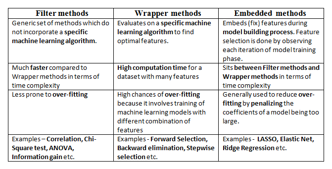

## Univariate selection - Python - 1

- scikit-learn library provides the SelectKBest class that can be used with a suite of different statistical tests

```python
import pandas as pd
import numpy as np

data = pd.read_csv('https://raw.githubusercontent.com/urosgodnov/datasets/master/BT.csv')

X = data.iloc[:,0:20]  #independent columns
y = data.iloc[:,-1]

X.columns
```

```
## Index(['battery_power', 'blue', 'clock_speed', 'dual_sim', 'fc', 'four_g',
##        'int_memory', 'm_dep', 'mobile_wt', 'n_cores', 'pc', 'px_height',
##        'px_width', 'ram', 'sc_h', 'sc_w', 'talk_time', 'three_g',
##        'touch_screen', 'wifi'],
##       dtype='object')
```

## Univariate selection - Python - 2

```python
from sklearn.feature_selection import SelectKBest
from sklearn.feature_selection import chi2

bestfeatures = SelectKBest(score_func=chi2, k=10)
fit = bestfeatures.fit(X,y)
dfscores = pd.DataFrame({'Score':fit.scores_,'pvalues':fit.pvalues_.round(4)})
dfcolumns = pd.DataFrame({'Spec':X.columns})

featureScores = pd.concat([dfcolumns,dfscores],axis=1)
featureScores.nlargest(10,'Score')
```

```
##              Spec          Score  pvalues
## 13            ram  931267.519053   0.0000
## 11      px_height   17363.569536   0.0000
## 0   battery_power   14129.866576   0.0000
## 12       px_width    9810.586750   0.0000
## 8       mobile_wt      95.972863   0.0000
## 6      int_memory      89.839124   0.0000
## 15           sc_w      16.480319   0.0009
## 16      talk_time      13.236400   0.0042
## 4              fc      10.135166   0.0175
## 14           sc_h       9.614878   0.0221
```

## Univariate selection - R - 1

```r
data<-read.csv('https://raw.githubusercontent.com/urosgodnov/datasets/master/BT.csv')

data<-data[,c(1:20,ncol(data))]

dependent<-data[,ncol(data),drop=FALSE]
```

## Univariate selection - R - 2

```r
library(FSinR)

evaluator <-filterEvaluator('chiSquared')

# Generates the direct search function with k-best
directSearcher <- directSearchAlgorithm('selectKBest', list(k=10))

features<- directFeatureSelection(data, colnames(dependent), directSearcher, evaluator)

result<-cbind(features$featuresSelected, features$valuePerFeature)
colnames(result)<-c("Spec","Score")
result
```

```
##       Spec            Score
##  [1,] "ram"           "5404.66666666667"
##  [2,] "px_height"     "3440.59047619048"
##  [3,] "battery_power" "3415.46666666667"
##  [4,] "px_width"      "3339.25714285714"
##  [5,] "mobile_wt"     "378.507287942262"
##  [6,] "int_memory"    "212.088413950827"
##  [7,] "sc_w"          "78.995185669173"
##  [8,] "pc"            "65.5039695118964"
##  [9,] "clock_speed"   "65.2635416500075"
## [10,] "fc"            "61.7989955293613"
```

## Correlation matrix - Python - 1

```python
import pandas as pd
import numpy as np
import matplotlib
import matplotlib.pyplot as plt
import seaborn as sns
from sklearn.datasets import load_boston

#Loading the dataset
x = load_boston()

data = pd.DataFrame(x.data, columns = x.feature_names)
data["MEDV"] = x.target
data.head()
```

```
##       CRIM    ZN  INDUS  CHAS    NOX  ...    TAX  PTRATIO       B  LSTAT  MEDV
## 0  0.00632  18.0   2.31   0.0  0.538  ...  296.0     15.3  396.90   4.98  24.0
## 1  0.02731   0.0   7.07   0.0  0.469  ...  242.0     17.8  396.90   9.14  21.6
## 2  0.02729   0.0   7.07   0.0  0.469  ...  242.0     17.8  392.83   4.03  34.7
## 3  0.03237   0.0   2.18   0.0  0.458  ...  222.0     18.7  394.63   2.94  33.4
## 4  0.06905   0.0   2.18   0.0  0.458  ...  222.0     18.7  396.90   5.33  36.2
##
## [5 rows x 14 columns]
```

## Correlation matrix - Python - 2

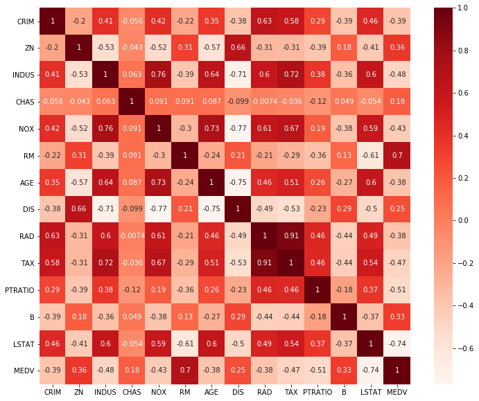

```python
plt.figure(figsize=(12,10))
cor = data.corr()
sns.heatmap(cor, annot=True, cmap=plt.cm.Reds)
plt.show()
```

## Correlation matrix - R

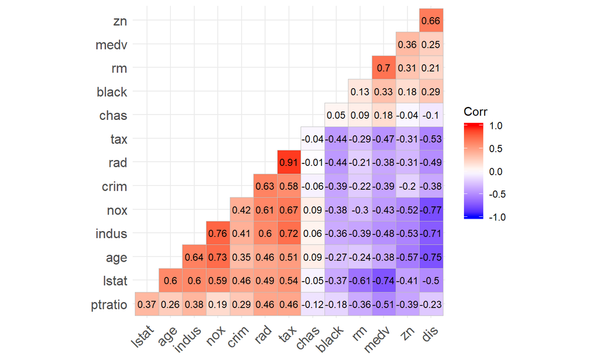

```r
library(ggcorrplot)
library(MASS)

corr<-cor(Boston)
ggcorrplot(corr, hc.order = TRUE, type = "lower",
   lab = TRUE, lab_size = 3)
```

## Feature Importance - Python

```python
import pandas as pd
import numpy as np
from sklearn.ensemble import ExtraTreesClassifier

data = pd.read_csv('https://raw.githubusercontent.com/urosgodnov/datasets/master/BT.csv')

X = data.iloc[:,0:20]  #independent columns
y = data.iloc[:,-1]
model = ExtraTreesClassifier().fit(X,y)

feat_importances = pd.Series(model.feature_importances_, index=X.columns)
feat_importances.nlargest(10)
```

```
## ram              0.383710
## battery_power    0.059061
## px_width         0.049021
## px_height        0.048368
## mobile_wt        0.037559
## int_memory       0.036366
## talk_time        0.035564
## sc_w             0.035042
## sc_h             0.034649
## pc               0.034498
## dtype: float64
```

## Feature Importance - R

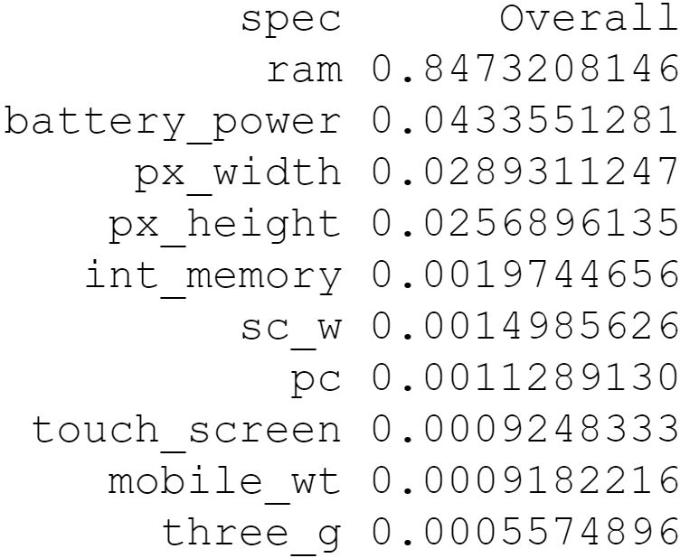

```r
library(caret)
library(extraTrees)

data<-read.csv('https://raw.githubusercontent.com/urosgodnov/datasets/master/BT.csv')

data<-data[,c(1:20,ncol(data))]

rrfMod <- train(price_range ~ ., data=data, method="extraTrees")
rrfImp <- varImp(rrfMod, scale=F)
result<-rrfImp[1]$importance
result$spec <- rownames(result)
head(result[order(-result$Overall),c(2,1)],10)
```

## Why is there a difference in extremeTress

- features are selected randomly for splitting

## Rule of thumb

- filter method is less accurate, but great when doing exploratory analysis; it can also be used for checking multi co-linearity in data.
- wrapper and embedded methods give more accurate results but as they are computationally expensive, these method are suited when you have lesser features (~20)

## Lab

- use mtcars dataset
- for pyhton use:

```python
data =
pd.read_csv('https://raw.githubusercontent.com/urosgodnov/datasets/master/mtcars.csv')
```

- inspect the dataset
- mpg variable is the target variable
- use feature selection (correlation matrix) to extract 3 most important features in python and r

## Solution - R

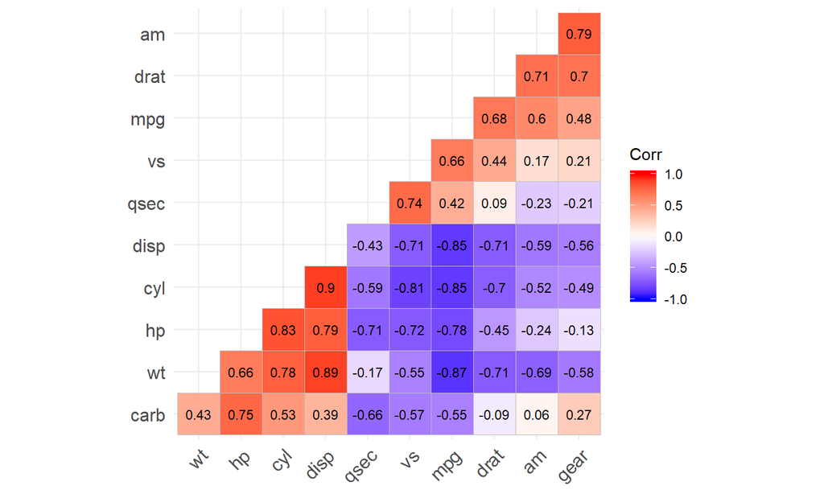

```r
library(ggcorrplot)
library(MASS)

corr<-cor(mtcars)
ggcorrplot(corr, hc.order = TRUE, type = "lower",
   lab = TRUE, lab_size = 3)
```

```r
# wt, cyl, hp; why not disp?
```

## Solution - Python

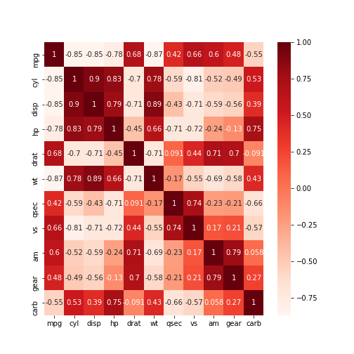

```python
import pandas as pd
import numpy as np
import matplotlib
import matplotlib.pyplot as plt
import seaborn as sns

data = pd.read_csv('https://raw.githubusercontent.com/urosgodnov/datasets/master/mtcars.csv')

cor = data.corr()
sns.heatmap(cor, annot=True, cmap=plt.cm.Reds)
plt.show()
```